**Lab #5 Markdown File**

[**Lab Instructions**](https://dssoc.github.io/assignments/lab_instructions.html)

In this lab we will be practicing the fundamentals of network analysis.

See the “Instructions” section of the [Introduction to Lab Assignments](https://dssoc.github.io/assignments/lab_instructions.html) page for more information about the labs. That page also gives descriptions for the datasets we will be using.

**Required reading:**

Theoretical:

- Chapter 3: Integrated Network Analysis Tutorial (see Slack)
- [Social Network Analysis Wikipedia](https://en.wikipedia.org/wiki/Social_network_analysis)
- [Network Centrality Measures on Wikipedia](https://en.wikipedia.org/wiki/Centrality)
- [Using Metadata to find Paul Revere](https://kieranhealy.org/blog/archives/2013/06/09/using-metadata-to-find-paul-revere/)

Practical:

- [R igraph Manual Pages](https://igraph.org/r/doc/aaa-igraph-package.html)
- [Official documentation for `ggraph` package](https://cran.r-project.org/web/packages/ggraph/ggraph.pdf)

**Optional resources:**

- [Official documentation for `igraph` package](https://igraph.org/r/doc/)
- [Official documentation for `ggraph` package](https://cran.r-project.org/web/packages/ggraph/ggraph.pdf)
- [Introduction to `ggraph` layouts](https://www.data-imaginist.com/2017/ggraph-introduction-layouts/)
- [Intro to Network Analysis with R, by Jesse Sadle](https://www.jessesadler.com/post/network-analysis-with-r/).
- [Network analysis with R and igraph: NetSci X Tutorial (Parts 2-7), by Katya Ognyanova](https://kateto.net/networks-r-igraph)
- [R4DS Chapters 17-21: Programming](https://r4ds.had.co.nz/program-intro.html)
- [Bipartite/Two-Mode Networks in igraph by Phil Murphy & Brendan Knapp](https://rpubs.com/pjmurphy/317838): specifically, the sections “Loading and configuring two-mode data” and “Another way to produce an overlap count in igraph bipartite_projection()”.
- [Bipartite Graph Wikipedia](https://en.wikipedia.org/wiki/Bipartite_graph)

## Lab Dataset

For most of this lab we will use the `common_subcomm` data frame in addition to our other data sets. This dataset lists the number of common subcommittees that each pair of congress members is on. Note that the “from” and “to” columns correspond to the `bioguide_id` of congress members, and `common_subcomm` is the number of common committees they are on.

```r
common_subcomm %>% head()
```

```
##      from      to common_subcomm
## 1 S001209 L000578              1
## 2 S001209 V000132              1
## 3 S001209 D000616              2
## 4 S001209 P000597              1
## 5 S001209 A000372              1
## 6 S001209 K000382              1
```

```r
common_subcomm %>% summary()
```

```
##      from                to            common_subcomm
##  Length:13851       Length:13851       Min.   : 1.000
##  Class :character   Class :character   1st Qu.: 1.000
##  Mode  :character   Mode  :character   Median : 1.000
##                                        Mean   : 1.576
##                                        3rd Qu.: 2.000
##                                        Max.   :12.000
```

## Example Questions

**ex1. Create an `igraph` graph from the data frame `common_committees`, and print the number of vertices and edges it has.**

```r
g <- common_subcomm %>% graph_from_data_frame()
V(g) %>% length()
```

```
## [1] 517
```

```r
E(g) %>% length()
```

```
## [1] 13851
```

**ex2. Create an `igraph` graph where edges only exist between congress members on at least 3 committees together. Output the number of edges that result.**

```r
# two ways to do this: filter before creating graph, or filter edges using igraph

# solution 1: filter before crreating graph
g <- common_subcomm %>%
  filter(common_subcomm >= 3) %>%
  graph_from_data_frame()

# solution 2: filter edges using igraph
h <- common_subcomm %>% graph_from_data_frame()
edges_to_remove <- E(h)[E(h)$common_subcomm < 3]
h <- h %>% delete_edges(edges_to_remove)

E(g) %>% length()
```

```
## [1] 1611
```

```r
E(h) %>% length()
```

```
## [1] 1611
```

```r
#node_attr <- congress %>% filter(bioguide_id %in% V(g))
#g %>% set_vertex_attr('full_name', index=node_attr$bioguide_id, value=node_attr$full_name)
```

**ex3. make a simple visualization of the previous network using ggraph.**

```
## Using "sugiyama" as default layout
```

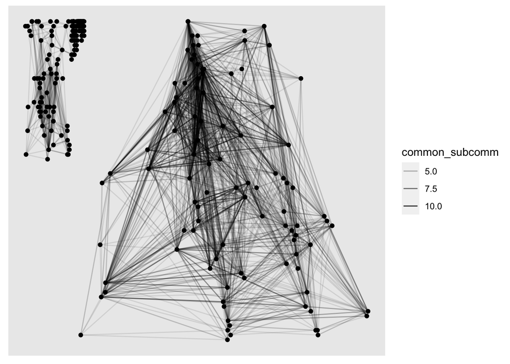

```r
g <- common_subcomm %>%
  filter(common_subcomm >= 3) %>%
  graph_from_data_frame()

g %>% ggraph() +
  geom_edge_link(aes(alpha=common_subcomm)) +
  geom_node_point()
```

**ex4. make a network that includes only senators, not representatives.**

```r
# two fine ways to do this - filter the dataframe before making the graph, or
# remove nodes after creating the graph

##################### solution 1 - filter dataframe first #####################
senators <- (congress %>% filter(type=='sen'))$bioguide_id
g <- common_subcomm %>%
  filter((to %in% senators) & (from %in% senators)) %>%
  graph_from_data_frame()

V(g) %>% length()
```

```
## [1] 99
```

```r
E(g) %>% length()
```

```
## [1] 2578
```

```r
##################### solution 2 - filter in graph #####################

# get ids of node set
node_ids <- c(common_subcomm$from, common_subcomm$to) %>% unique()

# get only rows of congress that are in the network - this will be used as node data
node_data <- congress %>% filter(bioguide_id %in% node_ids)

########### graph creation method 1: use the vertices argument in graph_from_data_frame to add all the vertex info
# this works because the first column of node_data is the bioguide_id.
h1 <- common_subcomm %>%
  graph_from_data_frame(vertices=node_data)

########### graph creation method 2: use set_vertex_attr to add the specific attribute to the graph after creating it
h2 <- common_subcomm %>%
  graph_from_data_frame()
h2 <- h2 %>% set_vertex_attr('type', index=node_data$bioguide_id, value=node_data$type)

# h1, h2 should the be the same
print(paste(gsize(h1), gsize(h2), gorder(h1), gorder(h2)))
```

```
## [1] "13851 13851 517 517"
```

```r
# filter out actual nodes
vertices_to_remove <- V(h1)[V(h1)$type!='sen']
h1 <- h1 %>% delete_vertices(vertices_to_remove)

# same as in solution 1
V(h1) %>% length()
```

```
## [1] 99
```

```r
E(h1) %>% length()
```

```
## [1] 2578
```

## Questions

**1. Describe the following concepts using the suggested readings or by searching on the web:**

```
Basic Elements of Networks
  nodes (also called "vertices"): Points that can have attributes that can be connected by edges.
  edges (also called "ties" or "links"): Connections between nodes that can have a attributes such as a weighted value.

Network Representations
  edge list: List of edges that shows how nodes are connected. Each edge on the list has a starting and ending node connection, and it can have a weight attribute.
  adjacency matrix: A matrix with 0's and 1's or weighted values if the corresponding row and column nodes have a connecting edge.

Types of networks
  directed vs undirected network: A directed network has edges that represent a direction (from, to) of connection between nodes, while an undirected network has edges without direction.
  weighted vs unweighted network: A weighted network has an attribute for "weight" on its edges, whereas an unweighted network does not.
```

**2. Using resources in the suggested readings and on the web, describe three different centrality measures that can be used to summarize the positions of specific nodes/vertices within a network: betweenness centrality, strength centrality, and eigenvector centrality. Give an example use case for each of these measures.**

HINT: see required reading about centrality measures on Wikipedia to get some ideas.

```
1. Betweenness Centrality: This is a quantification of the number of times a node is used as part of the shortest path between two other nodes. A use case is using it to determine which person in a network has the most control over the communication of information.

2. Strength Centrality: This is a quantification of how "strong" a node's connections are, that is, the sum of a node's edge weights. A use case is determining who has the most influence in a social network, where edges are more heavily weighted if they are stronger connections.

3. Eigenvector Centrality: This is a quantification of how much influence a node has in a network, which is calculated through giving a node a higher score if they are connected to nodes with higher scores. Therefore, nodes connected with more higher scoring nodes have higher scores. This can be applied to citation networks, where papers cited by highly scored papers are likely to have more influence in the scientific field.
```

**3. Describe the behavior of the following functions, including their outputs and the behavior of each argument/parameter.**

```
graph_from_data_frame: This function takes a dataframe as the first input, a dataframe containing vertice data, and whether the graph is directed. It outputs an igraph graph that can be used to create a visualization.
graph_from_edgelist: This function takes in a edge list, which has an edge in each row. It also takes a parameter that determines whether the graph is directed.

E(): This function takes in a graph object, a list of vertices to identify specific edges (p), a list of vertices to identify a path (path), and whether to use edge directions in (p) (directed) to output a the edges of a graph
V(): This function takes in a graph object and outputs a sequence of vertexes.

strength: This function takes in a graph, vertices for strength calculation (vids), which mode to calculuate degrees of vertices (mode), whether to count in loops (loops), and what weight vector to use (weights). It then returns the strength of the vertices (the sum of weights).
betweenness: This function takes in a graph, a list of vertices for calculation, whether the graph is directed, weights for edges, whether the score should be normalized, a list of edges for calculation, and the maximum path length for consideration. It then returns a score of betweenness centrality as calculuated by the number of shortest paths going through a vertex or edge.
```

**4. Examine the `common_subcomm` dataframe. Would we consider this as an adjacency matrix or edge list network representation? Is the network that can be constructed from this dataframe weighted/unweighted or directed/undirected? Use your substantive understanding of the data to answer these questions.**

```
Adjacency Matrix or Edge List?: Edge List
weighted/unweighted?: Weighted
directed/undirected?: Undirected
```

**5. Create a visualization showing a network of senators (NOT representatives) where edges exist only between those senators that are on at least three subcommittees. Set node color based on the gender of the senators. Do you see any patterns visually?**

HINT: see the example questions for some ideas of how to accomplish this.

```
## Using "stress" as default layout
```

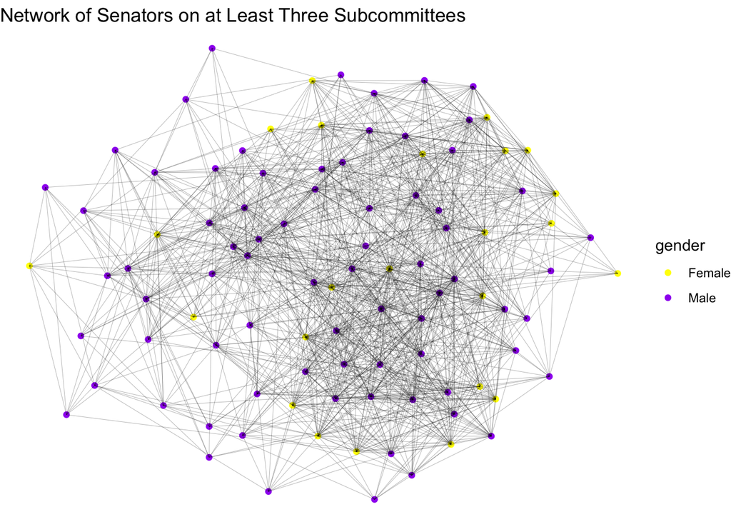

```
Patterns: It seems like there are more males on the outside of the network.
```

```r
senators <- (congress %>% filter(type=='sen'))

senate_net <- common_subcomm %>%
  filter((to %in% senators$bioguide_id) & (from %in% senators$bioguide_id)) %>%
  filter(common_subcomm >= 3)

senate_ids <- c(senate_net$from, senate_net$to) %>%
  unique()
senate_data <- senators %>%
  filter(bioguide_id %in% senate_ids)
# senators must be filtered to create a vertices list

senate_net %>%
  graph_from_data_frame(directed=FALSE, vertices=senate_data) %>%
  ggraph() +
  scale_color_manual(labels = c("Female", "Male"), values = c("yellow", "purple")) +
    geom_node_point(aes(color=gender)) +
    geom_edge_link(width=.05) +
    theme_void() +
  labs(fill = c("Female", "Male"), title = "Network of Senators on at Least Three Subcommittees")
```

**6. Find the average betweenness centrality (ignoring edge weights) of (ONLY) senators by gender after filtering edges that don’t have at least three common subcommittees.**

HINT: see `as_data_frame` for creating dataframes from node or edge attributes.

```r
senators <- (congress %>% filter(type=='sen'))
senate_net <- common_subcomm %>%
  filter((to %in% senators$bioguide_id) & (from %in% senators$bioguide_id)) %>%
  filter(common_subcomm < 3)
# don't have at least 3 subcommittees

senate_ids <- c(senate_net$from, senate_net$to) %>%
  unique()
senate_data <- senators %>%
  filter(bioguide_id %in% senate_ids)

senate_net <- senate_net %>%
  graph_from_data_frame(directed=FALSE, vertices=senate_data)

centrality_score <- as.data.frame(betweenness(senate_net)) %>%
  rownames_to_column(var = "bioguide_id") %>%
  inner_join(senate_data, by = "bioguide_id") %>%
  rename(score = `betweenness(senate_net)`)

centrality_score %>%
  group_by(gender) %>%
  summarise(average_betweenness_centrality=mean(score))
```

```
## # A tibble: 2 × 2
##   gender average_betweenness_centrality
##   <fct>                           <dbl>
## 1 F                                34.1
## 2 M                                35.2
```

**7. Compute the correlation between birthyear and betweenness centrality (ignoring edge weights) of senators, filtering for edges with fewer than three common subcommittees. What can you conclude from the sign (positive or negative) of this result?**

```r
cor(centrality_score$birthyear, centrality_score$score)
```

```
## [1] 0.3370284
```

```
Because the correlation is positive, the younger the senator, the higher the centrality score. It can then be concluded that the younger senators are correlated with more control over the flow of information in the network.
```

**8. Compare the average shortest path length for senator and representative networks after filtering for edges where congress members are on at least three common committees. Why are they different?**

```r
# senators
senators <- (congress %>% filter(type=='sen'))

senate_net <- common_subcomm %>%
  filter((to %in% senators$bioguide_id) & (from %in% senators$bioguide_id)) %>%
  filter(common_subcomm >= 3)

senate_ids <- c(senate_net$from, senate_net$to) %>%
  unique()
senate_data <- senators %>%
  filter(bioguide_id %in% senate_ids)

senate_net <- graph_from_data_frame(senate_net, directed=FALSE, vertices=senate_data)

print(paste("Senate Average Shortest Path Length:", mean_distance(senate_net)))
```

```
## [1] "Senate Average Shortest Path Length: 1.82519068233354"
```

```r
# representatives

representatives <- (congress %>% filter(type=='rep'))

rep_net <- common_subcomm %>%
  filter((to %in% representatives$bioguide_id) & (from %in% representatives$bioguide_id)) %>%
  filter(common_subcomm >= 3)

rep_ids <- c(rep_net$from, rep_net$to) %>%
  unique()
rep_data <- representatives %>%
  filter(bioguide_id %in% rep_ids)

rep_net <- graph_from_data_frame(rep_net, directed=FALSE, vertices=rep_data)

print(paste("Representatives Average Shortest Path Length:", mean_distance(rep_net)))
```

```
## [1] "Representatives Average Shortest Path Length: 3.57885865639297"
```

```
Why are they different?

Because there are more US representatives than US senators, the average shortest path to get from one node to another would be greater (there are more people, more connections, and therefore longer paths).
```

**9. In last week’s lab exercise, you were asked to identify several possible datasets you could use for your final project. Now write two specific data science research questions and describe variables in that dataset that could allow you to answer the questions.**

HINT: **What is a good research question?** A good data science research question specifies a relationship between two or more variables that you can measure. The question “why did the chicken cross the road?” is not a good research question because it does not explicitly describe the relationship between any variables. The question “do chickens cross the road more frequently than raccoons?” is good because it specifies a relationship between the type of animal (chickens and raccoons) and the frequency with which the animal crosses the road. Your question should be answerable given the specific variables available in your dataset.

```
Research Question 1:
How has social media impacted the visitor rates of National Parks?

https://irma.nps.gov/Stats/Reports/National
Variables:
- Number of visitors
- Variable analysis of network of National Park Instagram accounts
- Analysis of number of posts located at a National Park

Research Question 2:
How big of an impact do public libraries have on rural areas?

https://www.imls.gov/research-evaluation/data-collection/public-libraries-survey
Variables:
- Filter by rural areas
- Public computer usage (compared to number of households with computers from US Census)
- Attendance at programs
- Library visits
- Internet Access (compared to number of households with internet access from US Census)
```